# Titanic - Prediction of Survival

## Setting the working directory and loading required packages

```r
setwd("/Users/harishagarwal/Desktop/Harish/Data Science Courses/Kaggle/Titanic")
library(ggplot2)
library(dplyr)
library(dummies)
```

## Loading the training and testing datasets

```r
df_train = read.csv("train.csv", header = T, na.strings = '')
df_test = read.csv("test.csv", header = T,  na.strings = '')
str(df_train)
```

```
'data.frame':   891 obs. of  12 variables:
 $ PassengerId: int  1 2 3 4 5 6 7 8 9 10 ...
 $ Survived   : int  0 1 1 1 0 0 0 0 1 1 ...
 $ Pclass     : int  3 1 3 1 3 3 1 3 3 2 ...
 $ Name       : Factor w/ 891 levels "Abbing, Mr. Anthony",..: 109 191 354 273 16 555 516 625 413 577 ...
 $ Sex        : Factor w/ 2 levels "female","male": 2 1 1 1 2 2 2 2 1 1 ...
 $ Age        : num  22 38 26 35 35 NA 54 2 27 14 ...
 $ SibSp      : int  1 1 0 1 0 0 0 3 0 1 ...
 $ Parch      : int  0 0 0 0 0 0 0 1 2 0 ...
 $ Ticket     : Factor w/ 681 levels "110152","110413",..: 524 597 670 50 473 276 86 396 345 133 ...
 $ Fare       : num  7.25 71.28 7.92 53.1 8.05 ...
 $ Cabin      : Factor w/ 147 levels "A10","A14","A16",..: NA 82 NA 56 NA NA 130 NA NA NA ...
 $ Embarked   : Factor w/ 3 levels "C","Q","S": 3 1 3 3 3 2 3 3 3 1 ...
```

```r
summary(df_train)
```

```
  PassengerId       Survived          Pclass                                         Name         Sex
 Min.   :  1.0   Min.   :0.0000   Min.   :1.000   Abbing, Mr. Anthony                  :  1   female:314
 1st Qu.:223.5   1st Qu.:0.0000   1st Qu.:2.000   Abbott, Mr. Rossmore Edward          :  1   male  :577
 Median :446.0   Median :0.0000   Median :3.000   Abbott, Mrs. Stanton (Rosa Hunt)     :  1
 Mean   :446.0   Mean   :0.3838   Mean   :2.309   Abelson, Mr. Samuel                  :  1
 3rd Qu.:668.5   3rd Qu.:1.0000   3rd Qu.:3.000   Abelson, Mrs. Samuel (Hannah Wizosky):  1
 Max.   :891.0   Max.   :1.0000   Max.   :3.000   Adahl, Mr. Mauritz Nils Martin       :  1
                                                  (Other)                              :885
      Age            SibSp           Parch             Ticket         Fare                Cabin     Embarked
 Min.   : 0.42   Min.   :0.000   Min.   :0.0000   1601    :  7   Min.   :  0.00   B96 B98    :  4   C   :168
 1st Qu.:20.12   1st Qu.:0.000   1st Qu.:0.0000   347082  :  7   1st Qu.:  7.91   C23 C25 C27:  4   Q   : 77
 Median :28.00   Median :0.000   Median :0.0000   CA. 2343:  7   Median : 14.45   G6         :  4   S   :644
 Mean   :29.70   Mean   :0.523   Mean   :0.3816   3101295 :  6   Mean   : 32.20   C22 C26    :  3   NA's:  2
 3rd Qu.:38.00   3rd Qu.:1.000   3rd Qu.:0.0000   347088  :  6   3rd Qu.: 31.00   D          :  3
 Max.   :80.00   Max.   :8.000   Max.   :6.0000   CA 2144 :  6   Max.   :512.33   (Other)    :186
 NA's   :177                                      (Other) :852                    NA's       :687
```

```r
head(df_train)
```

|  | PassengerId | Survived | Pclass | Name | Sex | Age | SibSp | Parch | Ticket | Fare | Cabin | Embarked |
| --- | --- | --- | --- | --- | --- | --- | --- | --- | --- | --- | --- | --- |
| 1 | 1 | 0 | 3 | Braund, Mr. Owen Harris | male | 22 | 1 | 0 | A/5 21171 | 7.2500 | NA | S |
| 2 | 2 | 1 | 1 | Cumings, Mrs. John Bradley (Florence Briggs Thayer) | female | 38 | 1 | 0 | PC 17599 | 71.2833 | C85 | C |
| 3 | 3 | 1 | 3 | Heikkinen, Miss. Laina | female | 26 | 0 | 0 | STON/O2. 3101282 | 7.9250 | NA | S |
| 4 | 4 | 1 | 1 | Futrelle, Mrs. Jacques Heath (Lily May Peel) | female | 35 | 1 | 0 | 113803 | 53.1000 | C123 | S |
| 5 | 5 | 0 | 3 | Allen, Mr. William Henry | male | 35 | 0 | 0 | 373450 | 8.0500 | NA | S |
| 6 | 6 | 0 | 3 | Moran, Mr. James | male | NA | 0 | 0 | 330877 | 8.4583 | NA | Q |

```r
summary(df_test)
```

```
  PassengerId         Pclass                                             Name         Sex           Age
 Min.   : 892.0   Min.   :1.000   Abbott, Master. Eugene Joseph            :  1   female:152   Min.   : 0.17
 1st Qu.: 996.2   1st Qu.:1.000   Abelseth, Miss. Karen Marie              :  1   male  :266   1st Qu.:21.00
 Median :1100.5   Median :3.000   Abelseth, Mr. Olaus Jorgensen            :  1                Median :27.00
 Mean   :1100.5   Mean   :2.266   Abrahamsson, Mr. Abraham August Johannes :  1                Mean   :30.27
 3rd Qu.:1204.8   3rd Qu.:3.000   Abrahim, Mrs. Joseph (Sophie Halaut Easu):  1                3rd Qu.:39.00
 Max.   :1309.0   Max.   :3.000   Aks, Master. Philip Frank                :  1                Max.   :76.00
                                  (Other)                                  :412                NA's   :86
     SibSp            Parch             Ticket         Fare                     Cabin     Embarked
 Min.   :0.0000   Min.   :0.0000   PC 17608:  5   Min.   :  0.000   B57 B59 B63 B66:  3   C:102
 1st Qu.:0.0000   1st Qu.:0.0000   113503  :  4   1st Qu.:  7.896   A34            :  2   Q: 46
 Median :0.0000   Median :0.0000   CA. 2343:  4   Median : 14.454   B45            :  2   S:270
 Mean   :0.4474   Mean   :0.3923   16966   :  3   Mean   : 35.627   C101           :  2
 3rd Qu.:1.0000   3rd Qu.:0.0000   220845  :  3   3rd Qu.: 31.500   C116           :  2
 Max.   :8.0000   Max.   :9.0000   347077  :  3   Max.   :512.329   (Other)        : 80
                                   (Other) :396   NA's   :1         NA's           :327
```

## Drop unnecessary columns which won’t be required for analysis

```r
df_train = df_train[, !colnames(df_train) %in% c("PassengerId", "Name", "Ticket")]
df_test = df_test[, !colnames(df_test) %in% c("Name", "Ticket")]
summary(df_train)
```

```
    Survived          Pclass          Sex           Age            SibSp           Parch             Fare
 Min.   :0.0000   Min.   :1.000   female:314   Min.   : 0.42   Min.   :0.000   Min.   :0.0000   Min.   :  0.00
 1st Qu.:0.0000   1st Qu.:2.000   male  :577   1st Qu.:20.12   1st Qu.:0.000   1st Qu.:0.0000   1st Qu.:  7.91
 Median :0.0000   Median :3.000                Median :28.00   Median :0.000   Median :0.0000   Median : 14.45
 Mean   :0.3838   Mean   :2.309                Mean   :29.70   Mean   :0.523   Mean   :0.3816   Mean   : 32.20
 3rd Qu.:1.0000   3rd Qu.:3.000                3rd Qu.:38.00   3rd Qu.:1.000   3rd Qu.:0.0000   3rd Qu.: 31.00
 Max.   :1.0000   Max.   :3.000                Max.   :80.00   Max.   :8.000   Max.   :6.0000   Max.   :512.33
                                               NA's   :177
         Cabin     Embarked
 B96 B98    :  4   C   :168
 C23 C25 C27:  4   Q   : 77
 G6         :  4   S   :644
 C22 C26    :  3   NA's:  2
 D          :  3
 (Other)    :186
 NA's       :687
```

## Find out the % of missing values

```r
df_train_cabin_missing = sum(is.na(df_train$Cabin))/length(df_train$Cabin)
print(df_train_cabin_missing)
```

```
[1] 0.7710438
```

```r
df_train_age_missing = sum(is.na(df_train$Age))/length(df_train$Age)
print(df_train_age_missing)
```

```
[1] 0.1986532
```

```r
table(df_train$Embarked)
```

```
  C   Q   S
168  77 644
```

## Converting Age and Fare variable from Numeric to Integer

```r
df_train$Age = as.integer(df_train$Age)
df_test$Age = as.integer(df_test$Age)
df_train$Fare = as.integer(df_train$Fare)
df_test$Fare = as.integer(df_test$Fare)
```

## Missing value treatment

#### Since Cabin is a categorical variable, we can replace NA’s with the mode or entirely drop the column because it has a lot of missing values

#### Since Age is a continuous variable, we’ll replace NA’s with the mean

#### Replace the 2 missing values in Embarked with the mode ‘S’

```r
# df_train$Cabin[is.na(df_train$Cabin)] = names(sort(-table(df_train$Cabin)))[1]
# print(sum(is.na(df_train$Cabin))/length(df_train$Cabin))
df_train$Cabin = NULL
df_test$Cabin = NULL
avg_age_train = mean(df_train$Age, na.rm = T)
df_train$Age[is.na(df_train$Age)] = avg_age_train
print(sum(is.na(df_train$Age))/length(df_train$Age))
```

```
[1] 0
```

```r
df_train$Embarked[is.na(df_train$Embarked)] = 'S'
table(df_train$Embarked)
```

```
  C   Q   S
168  77 646
```

```r
df_test$Fare[is.na(df_test$Fare)] = median(df_test$Fare)
```

#### Replace the missing value in test data in Age column with the mean age of train data

```r
df_test$Age[is.na(df_test$Age)] = avg_age_train
```

## Bivariate analysis between the dependent variable (survived) and other independent variables

### Embarked vs Survived

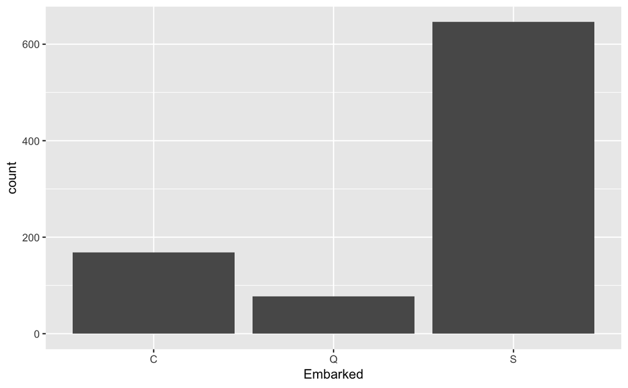

```r
df_train %>% ggplot(aes(x = Embarked)) + geom_bar()
```

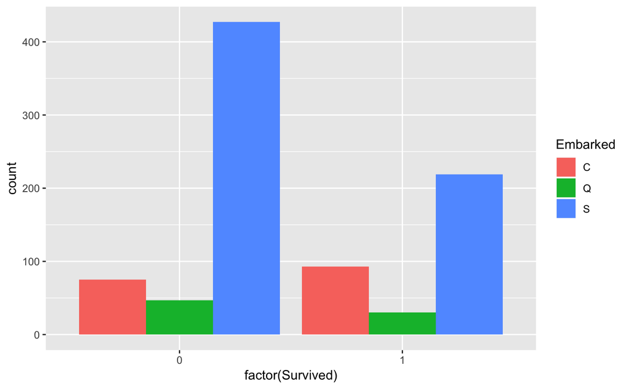

```r
df_train %>% ggplot(aes(x = factor(Survived), fill = Embarked)) + geom_bar(position = "dodge")
```

#### Let’s check the proportion of survived in each group

```r
df_train %>% group_by(Embarked) %>% summarise(mean = mean(Survived))
```

| Embarked | mean |
| --- | --- |
| C | 0.5535714 |
| Q | 0.3896104 |
| S | 0.3390093 |

#### Since S has the least % of survived passengers, we can create dummy variables and drop S

```r
df_train = cbind(df_train, dummy(df_train$Embarked, sep = "_"))
colnames(df_train)[(length(df_train)-2):length(df_train)] = c("Embarked_C", "Embarked_Q", "Embarked_S")
df_train$Embarked = NULL
df_train$Embarked_S = NULL
df_test = cbind(df_test, dummy(df_test$Embarked, sep = "_"))
colnames(df_test)[(length(df_test)-2):length(df_test)] = c("Embarked_C", "Embarked_Q", "Embarked_S")
df_test$Embarked = NULL
df_test$Embarked_S = NULL
```

### Sex vs Survived

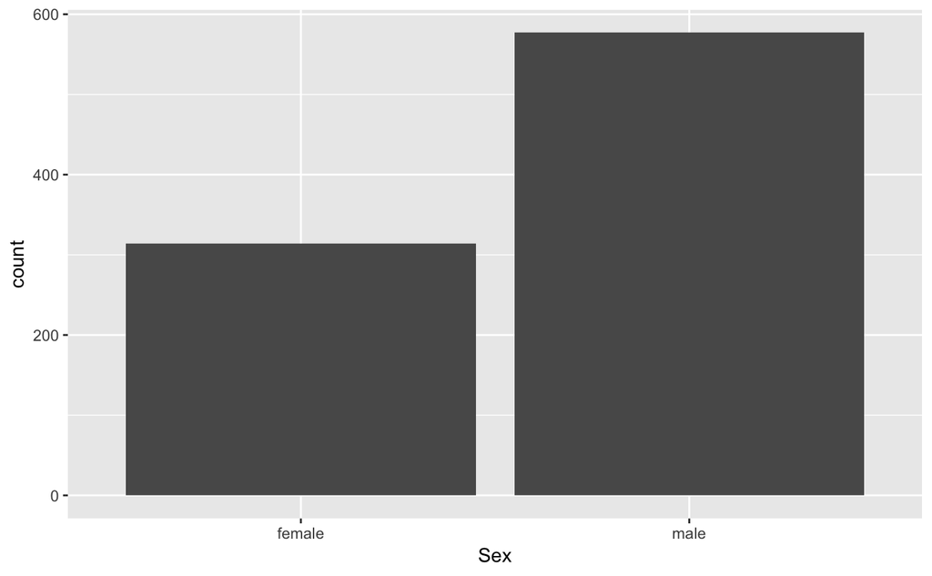

```r
df_train %>% ggplot(aes(x = Sex)) + geom_bar()
```

#### It can be seen that female passengers have the higher % of survival

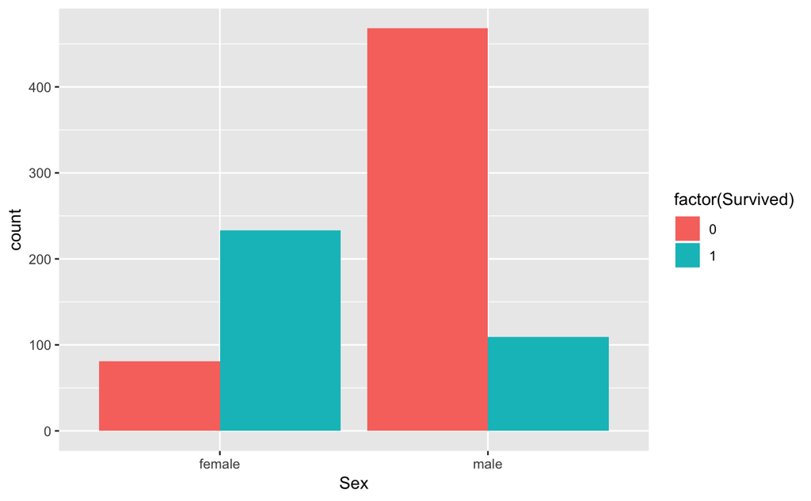

```r
df_train %>% ggplot(aes(x = Sex, fill = factor(Survived))) + geom_bar(position = "dodge")
```

```r
table(df_train$Sex, df_train$Survived)
```

```
           0   1
  female  81 233
  male   468 109
```

### Pclass vs Survived

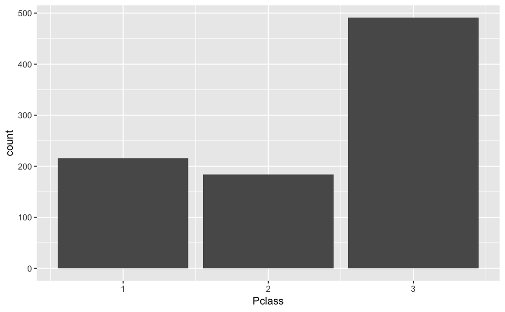

```r
df_train %>% ggplot(aes(x = Pclass)) + geom_bar()
```

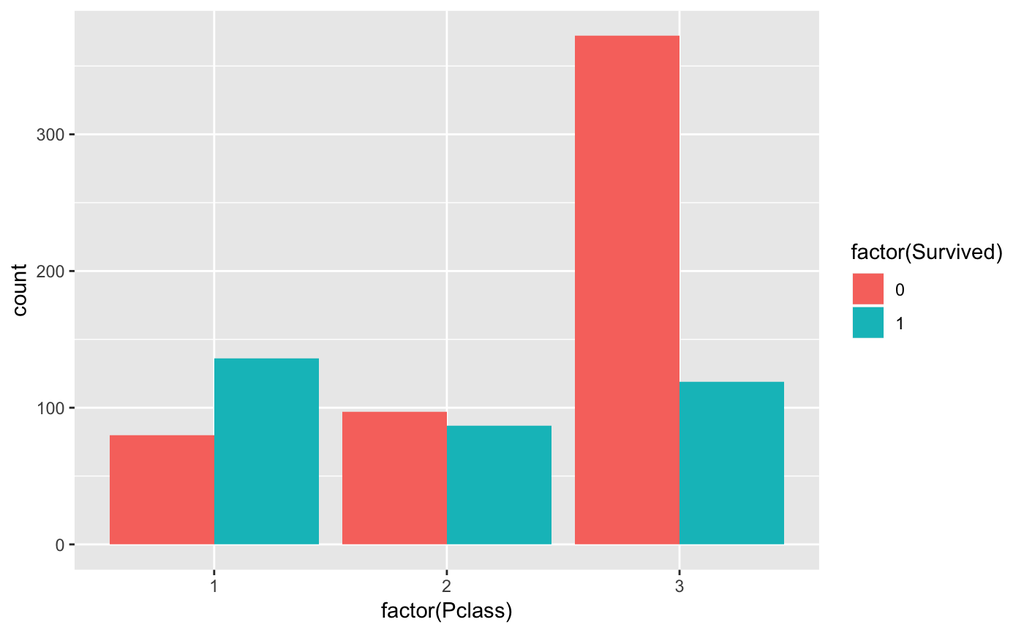

```r
df_train %>% ggplot(aes(x = factor(Pclass), fill = factor(Survived))) + geom_bar(position = "dodge")
```

#### Let’s check the proportion of survived in each group

```r
df_train %>% group_by(Pclass) %>% summarise(mean = mean(Survived))  # %>% ggplot(aes(x = factor(Pclass), y = mean)) + geom_point()
```

| Pclass | mean |
| --- | --- |
| 1 | 0.6296296 |
| 2 | 0.4728261 |
| 3 | 0.2423625 |

#### Since the 3rd Pclass has the minimum avg survival, we can drop it from the data

```r
df_train = cbind(df_train, dummy(df_train$Pclass, sep = "_"))
colnames(df_train)[(length(df_train)-2):length(df_train)] = c("Pclass_1", "Pclass_2", "Pclass_3")
df_train$Pclass_3 = NULL
df_train$Pclass = NULL
df_test = cbind(df_test, dummy(df_test$Pclass, sep = "_"))
colnames(df_test)[(length(df_test)-2):length(df_test)] = c("Pclass_1", "Pclass_2", "Pclass_3")
df_test$Pclass_3 = NULL
df_test$Pclass = NULL
```

### Age vs Survived

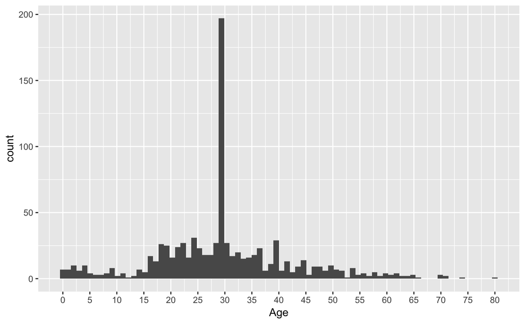

```r
df_train %>% ggplot(aes(x= Age)) + geom_histogram(bins = 80) +
  scale_x_continuous(breaks = seq(min(df_train$Age), max(df_train$Age), 5))
```

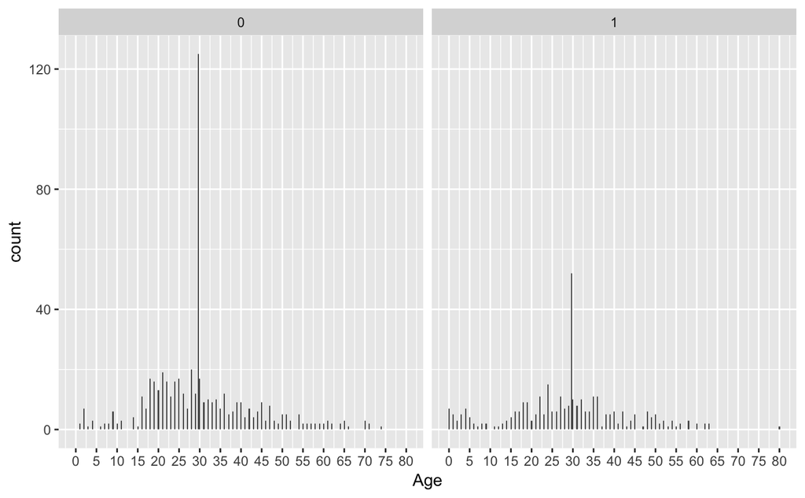

```r
df_train %>% ggplot(aes(x = Age)) + geom_bar() + facet_wrap(~Survived) +
  scale_x_continuous(breaks = seq(min(df_train$Age), max(df_train$Age), 5))
```

#### Let’s check the proportion of survived by age

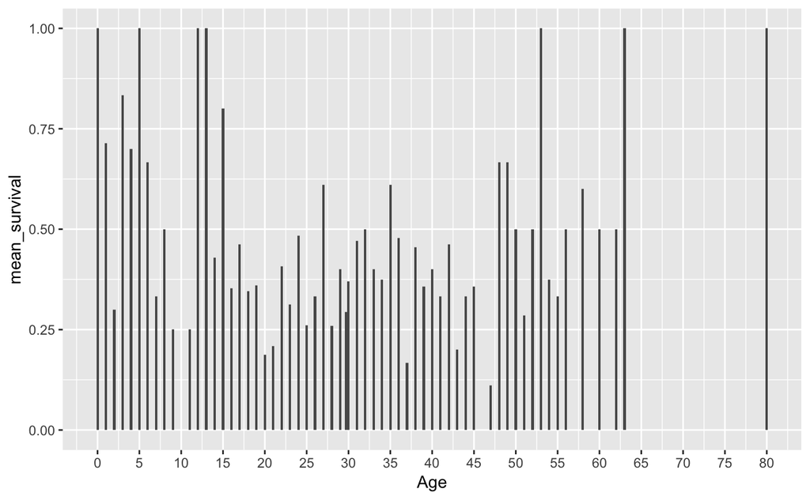

```r
df_train %>% group_by(Age) %>% summarise(mean_survival = mean(Survived)) %>%
  ggplot(aes(x = Age, y = mean_survival)) + geom_bar(stat = "Identity") +
  scale_x_continuous(breaks = seq(min(df_train$Age), max(df_train$Age), 5))
```

#### Let’s create different age groups based on above analysis

```r
df_train$Age_group = ifelse(df_train$Age <= 15, "Child", ifelse(df_train$Age > 15 & df_train$Age <= 45, "Adult", "Senior Citizen"))
df_train$Age = NULL
df_test$Age_group = ifelse(df_test$Age <= 15, "Child", ifelse(df_test$Age > 15 & df_test$Age <= 45, "Adult", "Senior Citizen"))
df_test$Age = NULL
```

### Let’s see if there is a relation between (Age Group - Sex) and Survived

#### From the plots, we can clearly assume that female adults survive more than the male adults.

```r
table(df_train$Sex, df_train$Age_group)
```

```
         Adult Child Senior Citizen
  female   241    43             30
  male     466    40             71
```

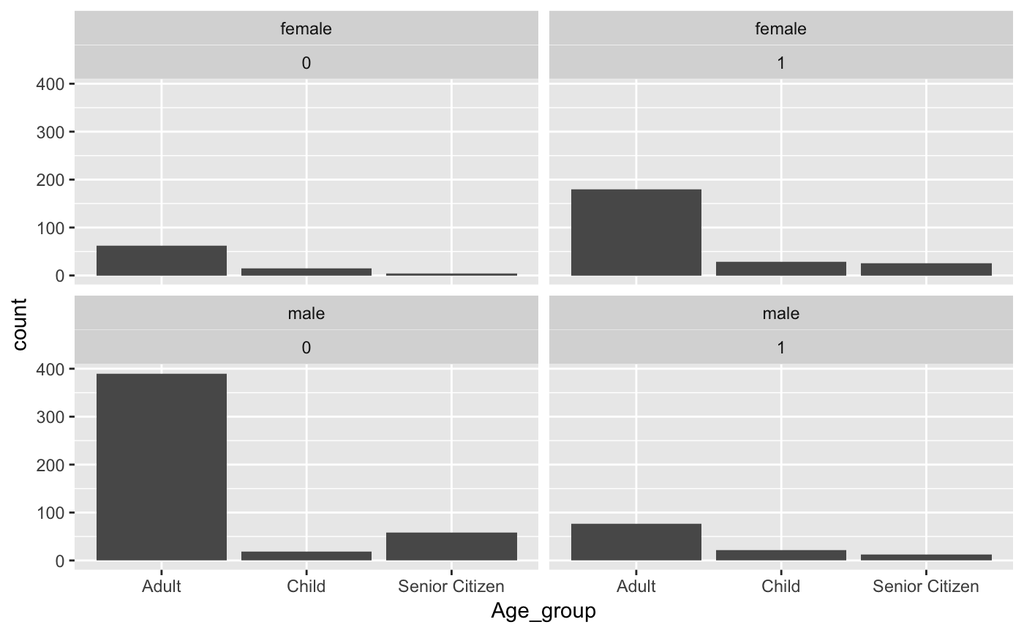

```r
df_train %>% ggplot(aes(x = Age_group)) + geom_bar() + facet_wrap(~Sex + Survived)
```

#### Creating dummy variables for Sex

```r
df_train = cbind(df_train, dummy(df_train$Sex, sep = "_"))
colnames(df_train)[(length(df_train)-1):length(df_train)] = c("Female", "Male")
df_train$Sex = NULL
df_test = cbind(df_test, dummy(df_test$Sex, sep = "_"))
colnames(df_test)[(length(df_test)-1):length(df_test)] = c("Female", "Male")
df_test$Sex = NULL
```

#### Creating dummy variables for Age Groups

```r
df_train = cbind(df_train, dummy(df_train$Age_group, sep = "_"))
colnames(df_train)[(length(df_train)-2):length(df_train)] = c("Adult", "Child", "Senior_Citizen")
df_train$Age_group = NULL
df_test = cbind(df_test, dummy(df_test$Age_group, sep = "_"))
colnames(df_test)[(length(df_test)-2):length(df_test)] = c("Adult", "Child", "Senior_Citizen")
df_test$Age_group = NULL
```

### For SibSp and Parch, let’s create a combined variable ‘Family’ if there are any siblings or parents together

```r
df_train$Family = ifelse((df_train$SibSp + df_train$Parch) > 0, 1, 0)
df_test$Family = ifelse((df_test$SibSp + df_test$Parch) > 0, 1, 0)
df_train$SibSp = df_train$Parch = NULL
df_test$SibSp = df_test$Parch = NULL
```

#### Now let’s see the relationship between Family and Survived

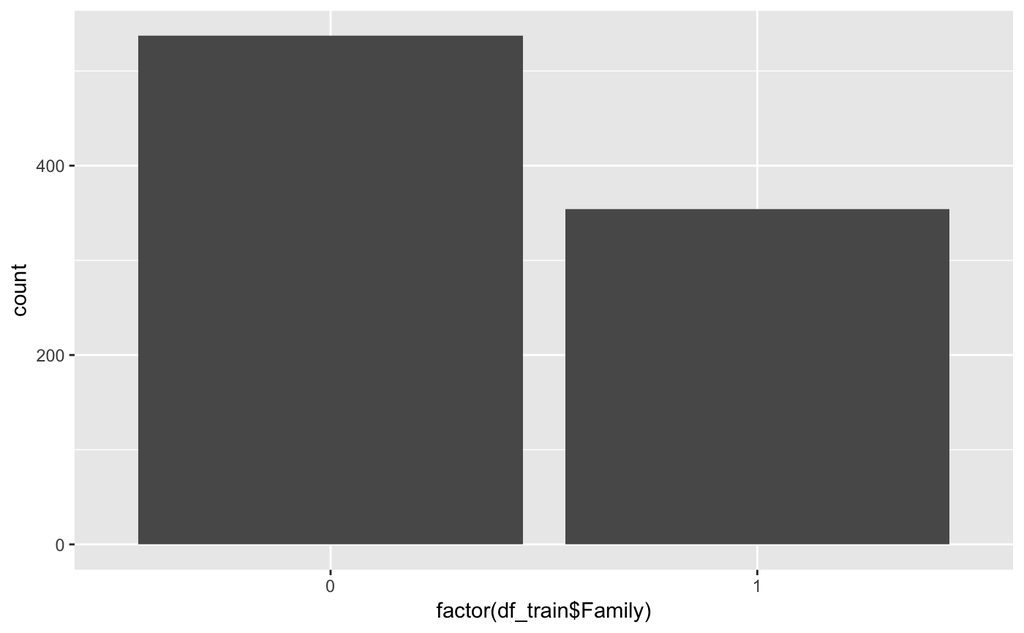

```r
df_train %>% ggplot(aes(x = factor(df_train$Family))) + geom_bar()
```

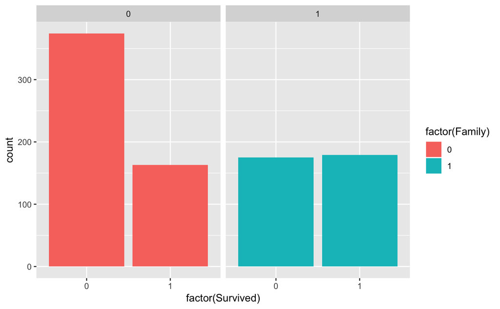

```r
df_train %>% ggplot(aes(x = factor(Survived), fill = factor(Family))) + geom_bar() + facet_wrap(~ Family)
```

### Fare vs Survived

#### The average fare of Survived passengers is lot higher than that of non-survived passengers

#### Thus, we can say that the passengers who paid higher fare are more likely to survive

```r
df_train %>% group_by(Survived) %>% summarise(mean_fare = mean(Fare), median_fare = median(Fare))
```

| Survived | mean_fare | median_fare |
| --- | --- | --- |
| 0 | 21.69035 | 10 |
| 1 | 47.99123 | 26 |

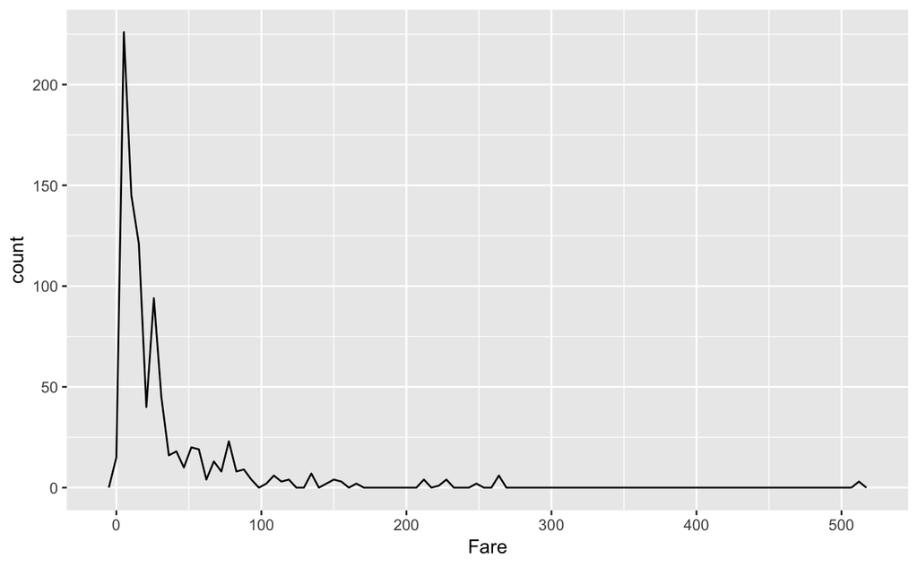

```r
df_train %>% ggplot(aes(x = Fare)) + geom_freqpoly(bins = 100)
```

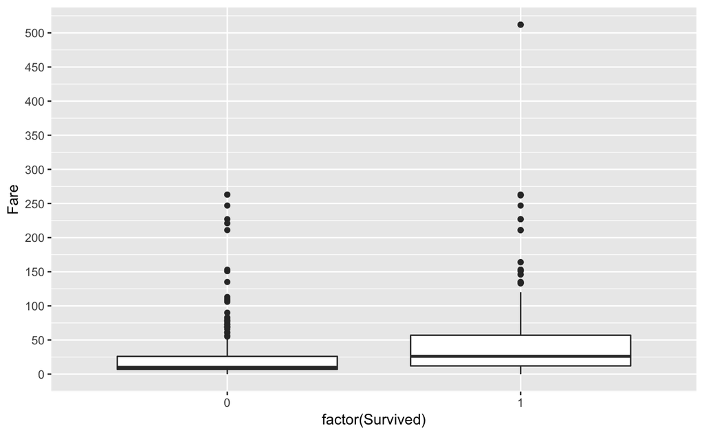

```r
df_train %>% ggplot(aes(x = factor(Survived), y = Fare)) + geom_boxplot() +
  scale_y_continuous(breaks = seq(min(df_train$Fare), max(df_train$Fare), 50))
```

## Creating models based on the EDA performed

### Logistic Model

```r
#train_Y = as.data.frame(df_train[Survived])
#train_X = as.data.frame(df_train[-c(df_train$Survived)])
glm_model = glm(Survived ~ ., data = df_train, family = "binomial")
summary(glm_model)
```

```
Call:
glm(formula = Survived ~ ., family = "binomial", data = df_train)

Deviance Residuals:
    Min       1Q   Median       3Q      Max
-2.6410  -0.6781  -0.3955   0.6548   2.3546

Coefficients: (2 not defined because of singularities)
                 Estimate Std. Error z value Pr(>|z|)
(Intercept)    -3.1819071  0.3411148  -9.328  < 2e-16 ***
Fare            0.0006907  0.0022385   0.309   0.7577
Embarked_C      0.5463894  0.2364747   2.311   0.0209 *
Embarked_Q      0.5269635  0.3193765   1.650   0.0989 .
Pclass_1        2.1833573  0.2823465   7.733 1.05e-14 ***
Pclass_2        1.3089488  0.2345645   5.580 2.40e-08 ***
Female          2.6151688  0.1975729  13.236  < 2e-16 ***
Male                   NA         NA      NA       NA
Adult           0.6682837  0.2914783   2.293   0.0219 *
Child           1.9341424  0.4201384   4.604 4.15e-06 ***
Senior_Citizen         NA         NA      NA       NA
Family         -0.1986375  0.2073813  -0.958   0.3381
---
Signif. codes:  0 '***' 0.001 '**' 0.01 '*' 0.05 '.' 0.1 ' ' 1

(Dispersion parameter for binomial family taken to be 1)

    Null deviance: 1186.66  on 890  degrees of freedom
Residual deviance:  795.51  on 881  degrees of freedom
AIC: 815.51

Number of Fisher Scoring iterations: 5
```

#### Removing the insignificant variables from the model

```r
glm_model = glm(Survived ~ Embarked_C + Embarked_Q + Pclass_1 + Pclass_2 + Female + Adult + Child, data = df_train, family = "binomial")
summary(glm_model)
```

```
Call:
glm(formula = Survived ~ Embarked_C + Embarked_Q + Pclass_1 +
    Pclass_2 + Female + Adult + Child, family = "binomial", data = df_train)

Deviance Residuals:
    Min       1Q   Median       3Q      Max
-2.6112  -0.7106  -0.3869   0.6886   2.2933

Coefficients:
            Estimate Std. Error z value Pr(>|z|)
(Intercept)  -3.2310     0.3383  -9.550  < 2e-16 ***
Embarked_C    0.5431     0.2338   2.323   0.0202 *
Embarked_Q    0.5580     0.3165   1.763   0.0779 .
Pclass_1      2.2035     0.2474   8.907  < 2e-16 ***
Pclass_2      1.3070     0.2337   5.593 2.24e-08 ***
Female        2.5661     0.1882  13.635  < 2e-16 ***
Adult         0.6763     0.2907   2.326   0.0200 *
Child         1.8369     0.4023   4.566 4.98e-06 ***
---
Signif. codes:  0 '***' 0.001 '**' 0.01 '*' 0.05 '.' 0.1 ' ' 1

(Dispersion parameter for binomial family taken to be 1)

    Null deviance: 1186.66  on 890  degrees of freedom
Residual deviance:  796.44  on 883  degrees of freedom
AIC: 812.44

Number of Fisher Scoring iterations: 5
```

#### Predict for the training data using the model and find the accuracy

```r
predict_train_glm = predict(glm_model, type = "response")
table(df_train$Survived, predict_train_glm > 0.5)
```

```
    FALSE TRUE
  0   454   95
  1    94  248
```

```r
accuracy_train_glm = (454+248)/(nrow(df_train))
print(accuracy_train_glm)
```

```
[1] 0.7878788
```

#### Plot ROC curve to check for better threshold

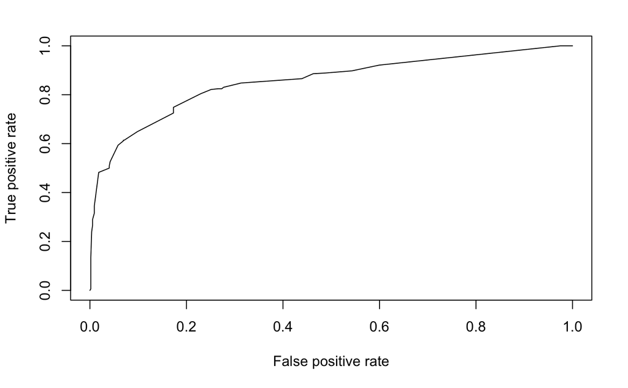

```r
library(ROCR)
ROCRpred = prediction(predict_train_glm, df_train$Survived)
ROCRperf = performance(ROCRpred, "tpr","fpr")
plot(ROCRperf)
```

#### Finding the AUC to find accuracy

```r
as.numeric(performance(ROCRpred, "auc")@y.values)
```

```
[1] 0.8531381
```

```r
table(df_train$Survived, predict_train_glm > 0.6)
```

```
    FALSE TRUE
  0   511   38
  1   132  210
```

```r
accuracy_train_glm = (511+210)/(nrow(df_train))
print(accuracy_train_glm)
```

```
[1] 0.8092031
```

### Rpart Trees

```r
library(rpart)
library(rpart.plot)
set.seed(3000)
tree_model = rpart(Survived ~ ., data = df_train, method = "class", minbucket = 25)
```

#### Plot the CART tree

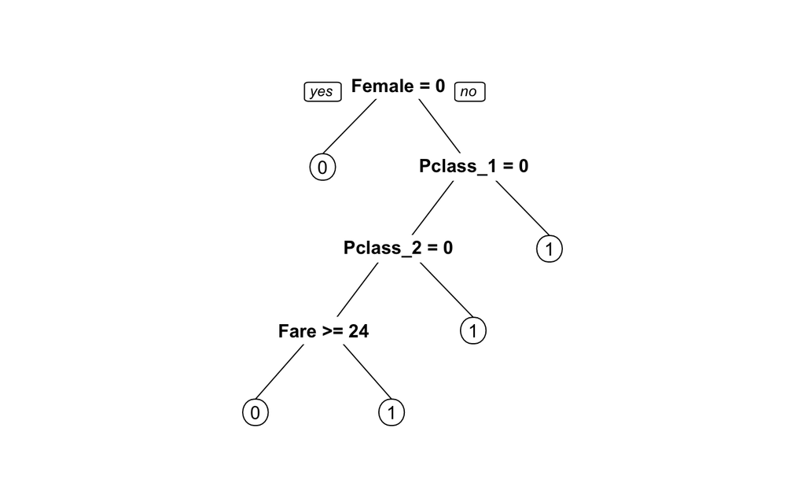

```r
prp(tree_model)
```

#### Predict using the model on the train data and find the accuracy

```r
predict_train_cart = predict(tree_model, type = "class")
table(df_train$Survived, predict_train_cart)
```

```
   predict_train_cart
      0   1
  0 491  58
  1 112 230
```

```r
accuracy_train_cart = (491+230)/nrow(df_train)
print(accuracy_train_cart)
```

```
[1] 0.8092031
```

### Random Forest

```r
library(randomForest)
df_train$Survived = as.factor(df_train$Survived)
set.seed(123)
randomforest_model = randomForest(Survived ~ ., data = df_train, ntree = 200)
```

#### Predict using the model on the train data and find the accuracy

```r
predict_train_rforest = predict(randomforest_model)
table(df_train$Survived, predict_train_rforest)
```

```
   predict_train_rforest
      0   1
  0 502  47
  1 111 231
```

```r
accuracy_train_rforest = (502+231)/nrow(df_train)
print(accuracy_train_rforest)
```

```
[1] 0.8226712
```

#### But how to select an optimum value of minbucket to prevent over-fitting or under-fitting?

#### Let’s use cross-validation to do this

```r
library(caret)
library(e1071)
numfolds = trainControl(method = 'cv', number = 10) #10-fold cross-validation
cpgrid = expand.grid(.cp = seq(0.01,0.5,0.01))
train(Survived ~ ., data = df_train, method = 'rpart', trControl = numfolds, tuneGrid = cpgrid)
```

```
CART

891 samples
 11 predictor
  2 classes: '0', '1'

No pre-processing
Resampling: Cross-Validated (10 fold)
Summary of sample sizes: 802, 801, 802, 802, 802, 802, ...
Resampling results across tuning parameters:

  cp    Accuracy   Kappa
  0.01  0.8058884  0.5747387
  0.02  0.7822671  0.5333039
  0.03  0.7867614  0.5419761
  0.04  0.7867614  0.5419761
  0.05  0.7867614  0.5419761
  0.06  0.7867614  0.5419761
  0.07  0.7867614  0.5419761
  0.08  0.7867614  0.5419761
  0.09  0.7867614  0.5419761
  0.10  0.7867614  0.5419761
  0.11  0.7867614  0.5419761
  0.12  0.7867614  0.5419761
  0.13  0.7867614  0.5419761
  0.14  0.7867614  0.5419761
  0.15  0.7867614  0.5419761
  0.16  0.7867614  0.5419761
  0.17  0.7867614  0.5419761
  0.18  0.7867614  0.5419761
  0.19  0.7867614  0.5419761
  0.20  0.7867614  0.5419761
  0.21  0.7867614  0.5419761
  0.22  0.7867614  0.5419761
  0.23  0.7867614  0.5419761
  0.24  0.7867614  0.5419761
  0.25  0.7867614  0.5419761
  0.26  0.7867614  0.5419761
  0.27  0.7867614  0.5419761
  0.28  0.7867614  0.5419761
```

[output cut: 10 more lines]

```
  0.39  0.7867614  0.5419761
  0.40  0.7867614  0.5419761
  0.41  0.7867614  0.5419761
  0.42  0.7867614  0.5419761
  0.43  0.7645392  0.4783643
  0.44  0.7263370  0.3592963
  0.45  0.6722001  0.1901147
  0.46  0.6161701  0.0000000
  0.47  0.6161701  0.0000000
  0.48  0.6161701  0.0000000
  0.49  0.6161701  0.0000000
  0.50  0.6161701  0.0000000

Accuracy was used to select the optimal model using the largest value.
The final value used for the model was cp = 0.01.
```

```r
tree_model_CV = rpart(Survived ~ ., data = df_train, method = "class", cp = 0.01)
```

#### Plot the CART tree

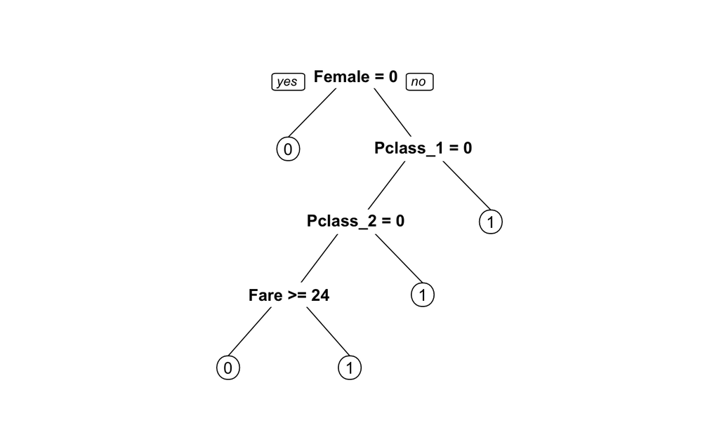

```r
prp(tree_model_CV)
```

#### Predict using the model on the train data and find the accuracy

```r
predict_train_cart_CV = predict(tree_model_CV, type = "class")
table(df_train$Survived, predict_train_cart_CV)
```

```
   predict_train_cart_CV
      0   1
  0 491  58
  1 112 230
```

```r
accuracy_train_cart_CV = (491+230)/nrow(df_train)
print(accuracy_train_cart_CV)
```

```
[1] 0.8092031
```

### SVM

```r
svm_model = svm(Survived ~ ., data = df_train)
```

#### Predict for the training data using the model and find the accuracy

```r
predict_train_svm = predict(svm_model)
table(df_train$Survived, predict_train_svm)
```

```
   predict_train_svm
      0   1
  0 527  22
  1 129 213
```

```r
accuracy_train_svm = (527+213)/(nrow(df_train))
print(accuracy_train_svm)
```

```
[1] 0.8305275
```

### Since all the above models give an accuracy of about 80%, let’s predict using the Logistic model since it’s easy to interpret

```r
summary(glm_model)
```

```
Call:
glm(formula = Survived ~ Embarked_C + Embarked_Q + Pclass_1 +
    Pclass_2 + Female + Adult + Child, family = "binomial", data = df_train)

Deviance Residuals:
    Min       1Q   Median       3Q      Max
-2.6112  -0.7106  -0.3869   0.6886   2.2933

Coefficients:
            Estimate Std. Error z value Pr(>|z|)
(Intercept)  -3.2310     0.3383  -9.550  < 2e-16 ***
Embarked_C    0.5431     0.2338   2.323   0.0202 *
Embarked_Q    0.5580     0.3165   1.763   0.0779 .
Pclass_1      2.2035     0.2474   8.907  < 2e-16 ***
Pclass_2      1.3070     0.2337   5.593 2.24e-08 ***
Female        2.5661     0.1882  13.635  < 2e-16 ***
Adult         0.6763     0.2907   2.326   0.0200 *
Child         1.8369     0.4023   4.566 4.98e-06 ***
---
Signif. codes:  0 '***' 0.001 '**' 0.01 '*' 0.05 '.' 0.1 ' ' 1

(Dispersion parameter for binomial family taken to be 1)

    Null deviance: 1186.66  on 890  degrees of freedom
Residual deviance:  796.44  on 883  degrees of freedom
AIC: 812.44

Number of Fisher Scoring iterations: 5
```

```r
predict_test_glm = predict(glm_model, newdata = df_test, type = "response")
df_test$Survived = as.numeric(predict_test_glm > 0.6)
df_test
```

| PassengerId | Fare | Embarked_C | Embarked_Q | Pclass_1 | Pclass_2 | Female | Male | Adult | Child | Senior_Citizen | Family | Survived |
| --- | --- | --- | --- | --- | --- | --- | --- | --- | --- | --- | --- | --- |
| 892 | 7 | 0 | 1 | 0 | 0 | 0 | 1 | 1 | 0 | 0 | 0 | 0 |
| 893 | 7 | 0 | 0 | 0 | 0 | 1 | 0 | 0 | 0 | 1 | 1 | 0 |
| 894 | 9 | 0 | 1 | 0 | 1 | 0 | 1 | 0 | 0 | 1 | 0 | 0 |
| 895 | 8 | 0 | 0 | 0 | 0 | 0 | 1 | 1 | 0 | 0 | 0 | 0 |
| 896 | 12 | 0 | 0 | 0 | 0 | 1 | 0 | 1 | 0 | 0 | 1 | 0 |
| 897 | 9 | 0 | 0 | 0 | 0 | 0 | 1 | 0 | 1 | 0 | 0 | 0 |
| 898 | 7 | 0 | 1 | 0 | 0 | 1 | 0 | 1 | 0 | 0 | 0 | 1 |
| 899 | 29 | 0 | 0 | 0 | 1 | 0 | 1 | 1 | 0 | 0 | 1 | 0 |
| 900 | 7 | 1 | 0 | 0 | 0 | 1 | 0 | 1 | 0 | 0 | 0 | 1 |
| 901 | 24 | 0 | 0 | 0 | 0 | 0 | 1 | 1 | 0 | 0 | 1 | 0 |

[output cut: 408 more lines]